# Mendelian Randomization Analysis: Insomnia and Alzheimer's Disease

By Dr. Shea Andrews, generated on 2018-09-09

```
## [1] FALSE
```

## Data sources

*Insomnia* [Lane et al Nat Genet 2017](https://www.nature.com/articles/ng.3749#supplementary-information): We report single- and multiple-trait genome-wide association analyses of self-reported sleep duration, insomnia symptoms and excessive daytime sleepiness in the UK Biobank (n = 112,586).

*Late Onset Alzheimer’s disease* [Lambert et al 2013](https://doi.org/10.1038/ng.2802): The International Genomics of Alzheimer’s Project (IGAP) is a meta-analysis of 4 previously published GWAS datasets: the European Alzheimer’s Disease Imitative (EADI), the Alzheimer Disease Genetics Consortium (ADGC), Cohorts for Heart and Aging Research in Genomic Epidemiology (CHARGE), and Genetic and Environmental Risk in AD (GERAD) and includes a sample of 17,008 LOAD cases and 37,154 cognitively normal elder controls. Participants in IGAP were of European ancestry, the average age was 71 and 58.4% of participants were women.

*Alzheimer’s Age of Onset Surivial* [Huang et al 2017](https://doi.org/10.1038/nn.4587): A GWAS of age of onset in LOAD was conducted in 14,406 AD case samples and 25,849 control samples from the IGAP using Cox proportional hazard regressions. Participants were of European ancestry, in cases the the average AAO was 74.8 and 61.7% were women, in controls the average AAE was 79.0 and 59.6% were women.

*CSF Ab42, tau & ptau* [Deming et al 2017](https://doi.org/10.1007/s00401-017-1685-y): A GWAS of CSF AB42, ptau and tau levels (pg/mL) was conducted in 3,146 participants. Participants were of Eurpean ancestry.

*Hippocampal Volume* [Hibar et al 2017](https://doi.org/10.1038/ncomms13624): A GWAS of hippocampal volume perfomed in 26,814 (ENIGMA and CHARGE consortiums) individules of European Ancestry discovered 9 independent loci.

## Instrumental Variables

**LD Clumping:** For standard two sample MR it is important to ensure that the instruments for the exposure are independent. LD clumping can be performed using the data_clump function from the TwoSampleMR package, which uses EUR samples from the 1000 genomes project to estimate LD between SNPs and amonst SNPs that have and LD above a given threshold, only the SNP with the lowest p-value will be retained.

**Proxy SNPs:** SNPs associated with Insomnia were extracted from the GWAS of LOAD, AAOS, AB42, ptau and tau. Where SNPs were not available in the outcome GWAS, the EUR thousand genomes was queried to identified potential proxy SNPs that are in linkage disequilibrium (r2 > 0.8) of the missing SNP.

### Insomnia

Insomnia: 267 SNPs (Table 1) were assoicated with were associated with Insomnia at p < 5e-6. After LD clumping, 228 of 267 SNPs were removed.

**Table 1:** Independent SNPS associated with Insomnia

| SNP | CHR | POS | Effect_allele | Non_Effect_allele | EAF | Beta | SE | P | r2 | N |
| --- | --- | --- | --- | --- | --- | --- | --- | --- | --- | --- |
| rs137863545 | 1 | 18009611 | T | G | 0.1699800 | -0.077191 | 0.016432 | 2.6498e-06 | 0.001681317 | 58702.10 |
| rs2807358 | 1 | 22491365 | C | T | 0.3843600 | -0.060826 | 0.012465 | 1.0527e-06 | 0.001750949 | 58702.00 |
| rs618932 | 1 | 58952414 | G | A | 0.0061709 | 0.389140 | 0.078871 | 7.5300e-07 | 0.001857385 | 58702.14 |
| rs74439783 | 1 | 98351869 | G | C | 0.0495130 | -0.128870 | 0.027859 | 3.7905e-06 | 0.001563144 | 58701.82 |
| rs114597228 | 1 | 195409243 | G | A | 0.0118840 | -0.272990 | 0.055850 | 1.0158e-06 | 0.001750226 | 58701.61 |
| rs7586784 | 2 | 3263577 | G | A | 0.0350640 | -0.152650 | 0.032759 | 3.2118e-06 | 0.001576825 | 58702.37 |
| rs6707939 | 2 | 28487706 | T | A | 0.2317500 | -0.068344 | 0.014843 | 4.0714e-06 | 0.001663233 | 58702.40 |
| rs113851554 | 2 | 66750564 | T | G | 0.0567100 | 0.232980 | 0.026487 | 9.1081e-19 | 0.005807272 | 58702.00 |
| rs11126082 | 2 | 66789341 | C | G | 0.4420000 | -0.056821 | 0.012380 | 4.4298e-06 | 0.001592591 | 58701.00 |
| rs79545773 | 2 | 67025545 | A | G | 0.0454200 | 0.144020 | 0.029646 | 1.1109e-06 | 0.001798602 | 58701.53 |

[output cut: 29 more lines]

### LOAD

**Table 2:** SNPS associated with Insomnia avalible in LOAD GWAS

| SNP | CHR | POS | Effect_allele | Non_Effect_allele | EAF | Beta | SE | P | r2 | N |
| --- | --- | --- | --- | --- | --- | --- | --- | --- | --- | --- |
| rs137863545 | 1 | 18007598 | T | G | 0.8371 | 0.0197 | 0.0223 | 0.3777 | 1.058427e-04 | 54162 |
| rs2807358 | 1 | 22491365 | T | C | 0.3766 | -0.0135 | 0.0161 | 0.4005 | 8.557455e-05 | 54162 |
| rs74439783 | 1 | 98351869 | G | C | 0.9569 | 0.0612 | 0.0506 | 0.2267 | 3.089418e-04 | 54162 |
| rs114597228 | 1 | 195409243 | G | A | 0.9871 | -0.0560 | 0.0684 | 0.4126 | 7.986508e-05 | 54162 |
| rs7586784 | 2 | 3263577 | G | A | 0.9668 | -0.0333 | 0.0438 | 0.4477 | 7.118577e-05 | 54162 |
| rs6707939 | 2 | 28487706 | A | T | 0.2357 | -0.0177 | 0.0210 | 0.3975 | 1.128756e-04 | 54162 |
| rs113851554 | 2 | 66750564 | T | G | 0.0636 | -0.0625 | 0.0474 | 0.1866 | 4.652738e-04 | 54162 |
| rs11126082 | 2 | 66789341 | C | G | 0.4335 | -0.0020 | 0.0167 | 0.9061 | 1.964622e-06 | 54162 |
| rs79545773 | 2 | 67025545 | A | G | 0.0422 | 0.0080 | 0.0424 | 0.8503 | 5.173652e-06 | 54162 |
| rs7560016 | 2 | 125227383 | A | C | 0.3202 | 0.0102 | 0.0165 | 0.5372 | 4.529318e-05 | 54162 |

[output cut: 25 more lines]

### AAOS

Of the the 39 SNPs associated with Insomnia, 36 were available in the AAOS GWAS (Table 3).

**Table 3:** SNPS associated with available in AAOS GWAS

| SNP | CHR | POS | Effect_allele | Non_Effect_allele | EAF | Beta | SE | P | r2 | N |
| --- | --- | --- | --- | --- | --- | --- | --- | --- | --- | --- |
| rs137863545 | 1 | 18009611 | T | G | 0.1631 | 0.0145 | 0.0183 | 0.42800 | 5.739757e-05 | 40255 |
| rs2807358 | 1 | 22491365 | T | C | 0.3766 | -0.0302 | 0.0197 | 0.12450 | 4.282437e-04 | 40255 |
| rs74439783 | 1 | 98351869 | C | G | 0.9569 | -0.0952 | 0.0492 | 0.05293 | 7.475629e-04 | 40255 |
| rs114597228 | 1 | 195409243 | A | G | 0.9871 | 0.0019 | 0.0611 | 0.97540 | 9.193652e-08 | 40255 |
| rs7586784 | 2 | 3263577 | A | G | 0.9668 | 0.0619 | 0.0343 | 0.07085 | 2.459722e-04 | 40255 |
| rs6707939 | 2 | 28487706 | A | T | 0.2357 | 0.0005 | 0.0320 | 0.98750 | 9.007275e-08 | 40255 |
| rs113851554 | 2 | 66750564 | T | G | 0.0636 | -0.0011 | 0.0573 | 0.98530 | 1.441232e-07 | 40255 |
| rs11126082 | 2 | 66789341 | C | G | 0.4335 | 0.0041 | 0.0263 | 0.87620 | 8.256324e-06 | 40255 |
| rs79545773 | 2 | 67025545 | A | G | 0.0422 | -0.0345 | 0.0310 | 0.26550 | 9.621781e-05 | 40255 |
| rs7560016 | 2 | 125227383 | A | C | 0.3202 | -0.0019 | 0.0130 | 0.88640 | 1.571592e-06 | 40255 |

[output cut: 26 more lines]

### AB42

**Table 4:** SNPS associated with Insomnia avalible in ab42 GWAS

| SNP | CHR | POS | Effect_allele | Non_Effect_allele | EAF | Beta | SE | P | r2 | N |
| --- | --- | --- | --- | --- | --- | --- | --- | --- | --- | --- |
| rs137863545 | 1 | 18007598 | T | G | 0.1758700 | 0.0115200 | 0.005490 | 0.03603 | 3.847002e-05 | 3100 |
| rs2807358 | 1 | 22491365 | T | C | 0.3747770 | 0.0009102 | 0.004336 | 0.83380 | 3.882501e-07 | 2660 |
| rs74439783 | 1 | 98351869 | G | C | 0.0435787 | 0.0024970 | 0.010540 | 0.81270 | 5.197453e-07 | 2698 |
| rs7586784 | 2 | 3263577 | G | A | 0.0348630 | 0.0105900 | 0.011110 | 0.34060 | 7.547022e-06 | 3110 |
| rs79545773 | 2 | 67025545 | A | G | 0.0370034 | -0.0025650 | 0.010150 | 0.80050 | 4.688902e-07 | 3064 |
| rs7560016 | 2 | 125227383 | A | C | 0.3350940 | 0.0011460 | 0.004311 | 0.79040 | 5.852294e-07 | 3083 |
| rs73082331 | 3 | 48994943 | A | G | 0.1114260 | 0.0010860 | 0.006172 | 0.86030 | 2.335446e-07 | 3079 |
| rs28660657 | 4 | 91302131 | G | A | 0.4366180 | 0.0045060 | 0.004020 | 0.26250 | 9.988884e-06 | 3094 |
| rs3957165 | 6 | 33784864 | C | T | 0.1726520 | 0.0055550 | 0.005124 | 0.27840 | 8.815723e-06 | 3115 |
| rs1964719 | 8 | 8709756 | C | G | 0.3834920 | 0.0009821 | 0.004338 | 0.82090 | 4.560752e-07 | 2674 |

[output cut: 15 more lines]

### Ptau

**Table 5:** SNPS associated with Insomnia avalible in Ptau GWAS

| SNP | CHR | POS | Effect_allele | Non_Effect_allele | EAF | Beta | SE | P | r2 | N |
| --- | --- | --- | --- | --- | --- | --- | --- | --- | --- | --- |
| rs137863545 | 1 | 18007598 | T | G | 0.1758700 | -0.0067510 | 0.007242 | 0.35130 | 1.321155e-05 | 2818 |
| rs2807358 | 1 | 22491365 | T | C | 0.3747770 | -0.0034600 | 0.005998 | 0.56410 | 5.610351e-06 | 2384 |
| rs74439783 | 1 | 98351869 | G | C | 0.0435787 | 0.0184700 | 0.014440 | 0.20120 | 2.843723e-05 | 2420 |
| rs7586784 | 2 | 3263577 | G | A | 0.0348630 | 0.0039870 | 0.014390 | 0.78180 | 1.069735e-06 | 2828 |
| rs79545773 | 2 | 67025545 | A | G | 0.0370034 | 0.0092180 | 0.013400 | 0.49150 | 6.055776e-06 | 2785 |
| rs7560016 | 2 | 125227383 | A | C | 0.3350940 | -0.0014810 | 0.005641 | 0.79290 | 9.773880e-07 | 2808 |
| rs73082331 | 3 | 48994943 | A | G | 0.1114260 | -0.0048540 | 0.008128 | 0.55040 | 4.665623e-06 | 2806 |
| rs28660657 | 4 | 91293693 | G | A | 0.4450110 | 0.0071800 | 0.005851 | 0.21990 | 2.546443e-05 | 2080 |
| rs6896861 | 5 | 17727683 | G | A | 0.4056980 | 0.0004255 | 0.006667 | 0.94910 | 8.730501e-08 | 1815 |
| rs3957165 | 6 | 33784864 | C | T | 0.1726520 | -0.0098470 | 0.006705 | 0.14210 | 2.770114e-05 | 2833 |

[output cut: 16 more lines]

### Tau

**Table 6:** SNPS associated with Insomnia avalible in tau GWAS

| SNP | CHR | POS | Effect_allele | Non_Effect_allele | EAF | Beta | SE | P | r2 | N |
| --- | --- | --- | --- | --- | --- | --- | --- | --- | --- | --- |
| rs137863545 | 1 | 18007598 | T | G | 0.1758700 | -0.0072570 | 0.007655 | 0.34320 | 1.526623e-05 | 3093 |
| rs2807358 | 1 | 22491365 | T | C | 0.3747770 | -0.0039780 | 0.006275 | 0.52620 | 7.415961e-06 | 2655 |
| rs74439783 | 1 | 98351869 | G | C | 0.0435787 | 0.0156500 | 0.015280 | 0.30600 | 2.041654e-05 | 2693 |
| rs7586784 | 2 | 3263577 | G | A | 0.0348630 | 0.0026010 | 0.015530 | 0.86700 | 4.552652e-07 | 3103 |
| rs79545773 | 2 | 67025545 | A | G | 0.0370034 | 0.0049500 | 0.014110 | 0.72570 | 1.746251e-06 | 3057 |
| rs7560016 | 2 | 125227383 | A | C | 0.3350940 | 0.0031840 | 0.006019 | 0.59690 | 4.517551e-06 | 3076 |
| rs73082331 | 3 | 48994943 | A | G | 0.1114260 | -0.0106900 | 0.008642 | 0.21630 | 2.262901e-05 | 3073 |
| rs28660657 | 4 | 91302131 | G | A | 0.4366180 | -0.0022730 | 0.005607 | 0.68530 | 2.541754e-06 | 3087 |
| rs3957165 | 6 | 33784864 | C | T | 0.1726520 | -0.0053650 | 0.007154 | 0.45340 | 8.222981e-06 | 3108 |
| rs1964719 | 8 | 8709756 | C | G | 0.3834920 | -0.0113600 | 0.006281 | 0.07055 | 6.102133e-05 | 2668 |

[output cut: 15 more lines]

### Hippocampal volume

Of the the 39 SNPs associated with Insomnia, 34 were available in the Hippocampal volume (Table 7).

**Table 7:** SNPS associated with Insomnia avalible in Hippocampal volume GWAS

| SNP | CHR | POS | Effect_allele | Non_Effect_allele | EAF | Zscore | Beta | SE | P | r2 | N |
| --- | --- | --- | --- | --- | --- | --- | --- | --- | --- | --- | --- |
| rs137863545 | 1 | 18009611 | T | G | 0.1728 | 0.511 | 0.0058581893 | 0.011464167 | 0.60950 | 9.810950e-06 | 26615 |
| rs2807358 | 1 | 22491365 | T | C | 0.3717 | -0.166 | -0.0014888461 | 0.008968953 | 0.86800 | 1.035355e-06 | 26615 |
| rs618932 | 1 | 58952414 | A | G | 0.0081 | -0.248 | -0.0144558683 | 0.058289791 | 0.80450 | 3.357927e-06 | 18316 |
| rs74439783 | 1 | 98351869 | C | G | 0.9527 | -0.186 | -0.0042211993 | 0.022694620 | 0.85280 | 1.605902e-06 | 21543 |
| rs114597228 | 1 | 195409243 | A | G | 0.9865 | 2.208 | 0.0878052086 | 0.039766852 | 0.02725 | 2.053532e-04 | 23736 |
| rs7586784 | 2 | 3263577 | A | G | 0.9667 | -0.666 | -0.0161258290 | 0.024212956 | 0.50540 | 1.674210e-05 | 26493 |
| rs6707939 | 2 | 28487706 | A | T | 0.2477 | -0.080 | -0.0008002683 | 0.010003353 | 0.93610 | 2.386812e-07 | 26814 |
| rs113851554 | 2 | 66750564 | T | G | 0.0626 | -0.033 | -0.0005937312 | 0.017991854 | 0.97360 | 4.137223e-08 | 26322 |
| rs11126082 | 2 | 66789341 | C | G | 0.4415 | -1.408 | -0.0122437332 | 0.008695833 | 0.15910 | 7.392845e-05 | 26814 |
| rs79545773 | 2 | 67025545 | A | G | 0.0439 | 0.818 | 0.0172412268 | 0.021077294 | 0.41330 | 2.495365e-05 | 26814 |

[output cut: 24 more lines]

## Data harmonization

Harmonize the exposure and outcome datasets so that the effect of a SNP on the exposure and the effect of that SNP on the outcome correspond to the same allele. The harmonise_data function from the TwoSampleMR package can be used to perform the harmonization step, by default it try’s to infer the forward strand alleles using allele frequency information. EAF were not availbe in the IGAP summary statisitics, as such the allele frequencies reported in the AAOS anaylsis were used.

### Insomnia ~ LOAD

**Table 8:** Harmonized Insomnia and LOAD datasets

| SNP | effect_allele.exposure | other_allele.exposure | effect_allele.outcome | other_allele.outcome | beta.exposure | beta.outcome | eaf.exposure | eaf.outcome | se.outcome | pval.outcome | se.exposure | pval.exposure |
| --- | --- | --- | --- | --- | --- | --- | --- | --- | --- | --- | --- | --- |
| rs10156602 | G | A | G | A | -0.063263 | -0.0138 | 0.365030 | 0.6352 | 0.0162 | 0.3928 | 0.012713 | 6.4765e-07 |
| rs11126082 | C | G | C | G | -0.056821 | -0.0020 | 0.442000 | 0.4335 | 0.0167 | 0.9061 | 0.012380 | 4.4298e-06 |
| rs112974218 | T | C | T | C | -0.181170 | 0.1214 | 0.033701 | 0.0346 | 0.0855 | 0.1557 | 0.036606 | 7.4874e-07 |
| rs113851554 | T | G | T | G | 0.232980 | -0.0625 | 0.056710 | 0.0636 | 0.0474 | 0.1866 | 0.026487 | 9.1081e-19 |
| rs114597228 | G | A | G | A | -0.272990 | -0.0560 | 0.011884 | 0.9871 | 0.0684 | 0.4126 | 0.055850 | 1.0158e-06 |
| rs11854314 | T | C | T | C | 0.095207 | -0.0016 | 0.110300 | 0.1034 | 0.0263 | 0.9513 | 0.019681 | 1.2729e-06 |
| rs12160891 | G | A | G | A | 0.088070 | -0.0384 | 0.115420 | 0.8821 | 0.0257 | 0.1359 | 0.019159 | 4.1760e-06 |
| rs12240289 | A | T | A | T | -0.070603 | 0.0194 | 0.253880 | 0.2619 | 0.0191 | 0.3081 | 0.014298 | 7.9313e-07 |
| rs12799526 | G | A | G | A | 0.098397 | 0.0900 | 0.094775 | 0.9358 | 0.0629 | 0.1520 | 0.020731 | 2.0018e-06 |
| rs12904775 | T | C | T | C | 0.089008 | -0.0036 | 0.114950 | 0.1214 | 0.0237 | 0.8802 | 0.019038 | 2.8501e-06 |

[output cut: 25 more lines]

### Insomnia ~ AAOS

**Table 9:** Harmonized Insomnia and AAOS datasets

| SNP | effect_allele.exposure | other_allele.exposure | effect_allele.outcome | other_allele.outcome | beta.exposure | beta.outcome | eaf.exposure | eaf.outcome | se.outcome | pval.outcome | se.exposure | pval.exposure |
| --- | --- | --- | --- | --- | --- | --- | --- | --- | --- | --- | --- | --- |
| rs10156602 | G | A | G | A | -0.063263 | 0.0095 | 0.365030 | 0.3648 | 0.0195 | 0.62830 | 0.012713 | 6.4765e-07 |
| rs11126082 | C | G | C | G | -0.056821 | 0.0041 | 0.442000 | 0.4335 | 0.0263 | 0.87620 | 0.012380 | 4.4298e-06 |
| rs112974218 | T | C | T | C | -0.181170 | 0.0876 | 0.033701 | 0.0346 | 0.0853 | 0.30450 | 0.036606 | 7.4874e-07 |
| rs113851554 | T | G | T | G | 0.232980 | -0.0011 | 0.056710 | 0.0636 | 0.0573 | 0.98530 | 0.026487 | 9.1081e-19 |
| rs114597228 | G | A | G | A | -0.272990 | -0.0019 | 0.011884 | 0.0129 | 0.0611 | 0.97540 | 0.055850 | 1.0158e-06 |
| rs11854314 | T | C | T | C | 0.095207 | 0.0274 | 0.110300 | 0.1034 | 0.0307 | 0.37180 | 0.019681 | 1.2729e-06 |
| rs12160891 | G | A | G | A | 0.088070 | -0.0125 | 0.115420 | 0.1179 | 0.0193 | 0.51600 | 0.019159 | 4.1760e-06 |
| rs12240289 | A | T | A | T | -0.070603 | 0.0116 | 0.253880 | 0.2619 | 0.0309 | 0.70830 | 0.014298 | 7.9313e-07 |
| rs12799526 | G | A | G | A | 0.098397 | -0.0183 | 0.094775 | 0.0642 | 0.0706 | 0.79520 | 0.020731 | 2.0018e-06 |
| rs12904775 | T | C | T | C | 0.089008 | 0.0010 | 0.114950 | 0.1214 | 0.0188 | 0.95560 | 0.019038 | 2.8501e-06 |

[output cut: 26 more lines]

### Insomnia ~ AB42

**Table 10:** Harmonized Insomnia and AB42 datasets

| SNP | effect_allele.exposure | other_allele.exposure | effect_allele.outcome | other_allele.outcome | beta.exposure | beta.outcome | eaf.exposure | eaf.outcome | se.outcome | pval.outcome | se.exposure | pval.exposure |
| --- | --- | --- | --- | --- | --- | --- | --- | --- | --- | --- | --- | --- |
| rs10156602 | G | A | G | A | -0.063263 | -0.0021300 | 0.365030 | 0.3422080 | 0.004209 | 0.61300 | 0.012713 | 6.4765e-07 |
| rs11854314 | T | C | T | C | 0.095207 | -0.0078660 | 0.110300 | 0.0981059 | 0.006734 | 0.24280 | 0.019681 | 1.2729e-06 |
| rs12160891 | G | A | G | A | 0.088070 | -0.0019310 | 0.115420 | 0.1277330 | 0.006209 | 0.75580 | 0.019159 | 4.1760e-06 |
| rs12240289 | A | T | A | T | -0.070603 | 0.0004105 | 0.253880 | 0.2419310 | 0.004771 | 0.93140 | 0.014298 | 7.9313e-07 |
| rs12904775 | T | C | T | C | 0.089008 | 0.0024260 | 0.114950 | 0.1246230 | 0.006315 | 0.70090 | 0.019038 | 2.8501e-06 |
| rs137863545 | T | G | T | G | -0.077191 | 0.0115200 | 0.169980 | 0.1758700 | 0.005490 | 0.03603 | 0.016432 | 2.6498e-06 |
| rs150432464 | A | G | A | G | -0.162600 | -0.0260000 | 0.033503 | 0.0278873 | 0.014050 | 0.06423 | 0.034288 | 2.1383e-06 |
| rs1544725 | A | C | A | C | -0.099532 | -0.0085580 | 0.090004 | 0.0993532 | 0.006802 | 0.20850 | 0.021366 | 3.2228e-06 |
| rs1964719 | C | G | C | G | -0.058669 | 0.0009821 | 0.368070 | 0.3834920 | 0.004338 | 0.82090 | 0.012507 | 2.7213e-06 |
| rs208824 | C | T | C | T | 0.056536 | 0.0030790 | 0.441980 | 0.4448570 | 0.004046 | 0.44670 | 0.012289 | 4.1883e-06 |

[output cut: 15 more lines]

### Insomnia ~ Ptau

**Table 11:** Harmonized Insomnia and Ptau datasets

| SNP | effect_allele.exposure | other_allele.exposure | effect_allele.outcome | other_allele.outcome | beta.exposure | beta.outcome | eaf.exposure | eaf.outcome | se.outcome | pval.outcome | se.exposure | pval.exposure |
| --- | --- | --- | --- | --- | --- | --- | --- | --- | --- | --- | --- | --- |
| rs10156602 | G | A | G | A | -0.063263 | 0.0118100 | 0.365030 | 0.3422080 | 0.005549 | 0.03336 | 0.012713 | 6.4765e-07 |
| rs11854314 | T | C | T | C | 0.095207 | -0.0014570 | 0.110300 | 0.0981059 | 0.008811 | 0.86870 | 0.019681 | 1.2729e-06 |
| rs12160891 | G | A | G | A | 0.088070 | 0.0082020 | 0.115420 | 0.1277330 | 0.008083 | 0.31030 | 0.019159 | 4.1760e-06 |
| rs12240289 | A | T | A | T | -0.070603 | -0.0037480 | 0.253880 | 0.2419310 | 0.006698 | 0.57590 | 0.014298 | 7.9313e-07 |
| rs12904775 | T | C | T | C | 0.089008 | -0.0028500 | 0.114950 | 0.1246230 | 0.008247 | 0.72970 | 0.019038 | 2.8501e-06 |
| rs137863545 | T | G | T | G | -0.077191 | -0.0067510 | 0.169980 | 0.1758700 | 0.007242 | 0.35130 | 0.016432 | 2.6498e-06 |
| rs150432464 | A | G | A | G | -0.162600 | 0.0080550 | 0.033503 | 0.0278873 | 0.018650 | 0.66590 | 0.034288 | 2.1383e-06 |
| rs1544725 | A | C | A | C | -0.099532 | 0.0039510 | 0.090004 | 0.0956267 | 0.009582 | 0.68010 | 0.021366 | 3.2228e-06 |
| rs1964719 | C | G | C | G | -0.058669 | -0.0007468 | 0.368070 | 0.3834920 | 0.006000 | 0.90090 | 0.012507 | 2.7213e-06 |
| rs208824 | C | T | C | T | 0.056536 | -0.0036500 | 0.441980 | 0.4448570 | 0.005292 | 0.49050 | 0.012289 | 4.1883e-06 |

[output cut: 16 more lines]

### Insomnia ~ Tau

**Table 12:** Harmonized Insomnia and Tau datasets

| SNP | effect_allele.exposure | other_allele.exposure | effect_allele.outcome | other_allele.outcome | beta.exposure | beta.outcome | eaf.exposure | eaf.outcome | se.outcome | pval.outcome | se.exposure | pval.exposure |
| --- | --- | --- | --- | --- | --- | --- | --- | --- | --- | --- | --- | --- |
| rs10156602 | G | A | G | A | -0.063263 | 0.0093430 | 0.365030 | 0.3422080 | 0.005881 | 0.11220 | 0.012713 | 6.4765e-07 |
| rs11854314 | T | C | T | C | 0.095207 | 0.0041490 | 0.110300 | 0.0981059 | 0.009393 | 0.65880 | 0.019681 | 1.2729e-06 |
| rs12160891 | G | A | G | A | 0.088070 | 0.0054640 | 0.115420 | 0.1277330 | 0.008673 | 0.52880 | 0.019159 | 4.1760e-06 |
| rs12240289 | A | T | A | T | -0.070603 | -0.0024840 | 0.253880 | 0.2419310 | 0.006941 | 0.72050 | 0.014298 | 7.9313e-07 |
| rs12904775 | T | C | T | C | 0.089008 | -0.0101000 | 0.114950 | 0.1246230 | 0.008840 | 0.25350 | 0.019038 | 2.8501e-06 |
| rs137863545 | T | G | T | G | -0.077191 | -0.0072570 | 0.169980 | 0.1758700 | 0.007655 | 0.34320 | 0.016432 | 2.6498e-06 |
| rs150432464 | A | G | A | G | -0.162600 | 0.0092140 | 0.033503 | 0.0278873 | 0.019560 | 0.63760 | 0.034288 | 2.1383e-06 |
| rs1544725 | A | C | A | C | -0.099532 | -0.0033100 | 0.090004 | 0.0993532 | 0.009452 | 0.72630 | 0.021366 | 3.2228e-06 |
| rs1964719 | C | G | C | G | -0.058669 | -0.0113600 | 0.368070 | 0.3834920 | 0.006281 | 0.07055 | 0.012507 | 2.7213e-06 |
| rs208824 | C | T | C | T | 0.056536 | 0.0032840 | 0.441980 | 0.4448570 | 0.005647 | 0.56090 | 0.012289 | 4.1883e-06 |

[output cut: 15 more lines]

### Insomnia ~ Hippocampal Volume

**Table 13:** Harmonized Insomnia and Hippocampal Volume datasets

| SNP | effect_allele.exposure | other_allele.exposure | effect_allele.outcome | other_allele.outcome | beta.exposure | beta.outcome | eaf.exposure | eaf.outcome | se.outcome | pval.outcome | se.exposure | pval.exposure |
| --- | --- | --- | --- | --- | --- | --- | --- | --- | --- | --- | --- | --- |
| rs10156602 | G | A | G | A | -0.063263 | 0.0055570531 | 0.3650300 | 0.3780 | 0.008905534 | 0.53260 | 0.012713 | 6.4765e-07 |
| rs11126082 | C | G | C | G | -0.056821 | -0.0122437332 | 0.4420000 | 0.4415 | 0.008695833 | 0.15910 | 0.012380 | 4.4298e-06 |
| rs113851554 | T | G | T | G | 0.232980 | -0.0005937312 | 0.0567100 | 0.0626 | 0.017991854 | 0.97360 | 0.026487 | 9.1081e-19 |
| rs114597228 | G | A | G | A | -0.272990 | -0.0878052086 | 0.0118840 | 0.0135 | 0.039766852 | 0.02725 | 0.055850 | 1.0158e-06 |
| rs11854314 | T | C | T | C | 0.095207 | 0.0019413195 | 0.1103000 | 0.1106 | 0.013768224 | 0.88770 | 0.019681 | 1.2729e-06 |
| rs12160891 | G | A | G | A | 0.088070 | 0.0131479590 | 0.1154200 | 0.1210 | 0.013240643 | 0.32060 | 0.019159 | 4.1760e-06 |
| rs12240289 | A | T | A | T | -0.070603 | 0.0012932330 | 0.2538800 | 0.2735 | 0.009723557 | 0.89460 | 0.014298 | 7.9313e-07 |
| rs12904775 | T | C | T | C | 0.089008 | -0.0148241657 | 0.1149500 | 0.1211 | 0.013235862 | 0.26250 | 0.019038 | 2.8501e-06 |
| rs137863545 | T | G | T | G | -0.077191 | 0.0058581893 | 0.1699800 | 0.1728 | 0.011464167 | 0.60950 | 0.016432 | 2.6498e-06 |
| rs145265872 | T | C | T | C | -0.135450 | 0.0077807872 | 0.0451130 | 0.0430 | 0.021673502 | 0.71930 | 0.029556 | 4.6546e-06 |

[output cut: 24 more lines]

## Pleiotropy

Pleiotropy was assesed using Mendelian Randomization Pleiotropy RESidual Sum and Outlier (MR-PRESSO), that allows for the evlation of evaluation of horizontal pleiotropy in a standared MR model. MR-PRESSO performs a global test for detection of horizontal pleiotropy and correction of pleiotropy via outlier removal.

**Insomnia ~ LOAD:** The MR-PRESSO global test for pleiotropy was non-significant

**Insomnia ~ AAOS:** The MR-PRESSO global test for pleiotropy was non-significant.

**Insomnia ~ AB42:** The MR-PRESSO global test for pleiotropy was non-significant.

**Insomnia ~ Ptau:** The MR-PRESSO global test for pleiotropy was non-significant.

**Insomnia ~ Tau:** The MR-PRESSO global test for pleiotropy was non-significant..

**Insomnia ~ hippocampal volume:** The MR-PRESSO global test for pleiotropy was non-significant

## Mendelian Randomization Analysis

### Insomnia ~ LOAD

Figure 1 illustrates the SNP-specific associations with Insomnia versus the association between each SNP and risk of LOAD.

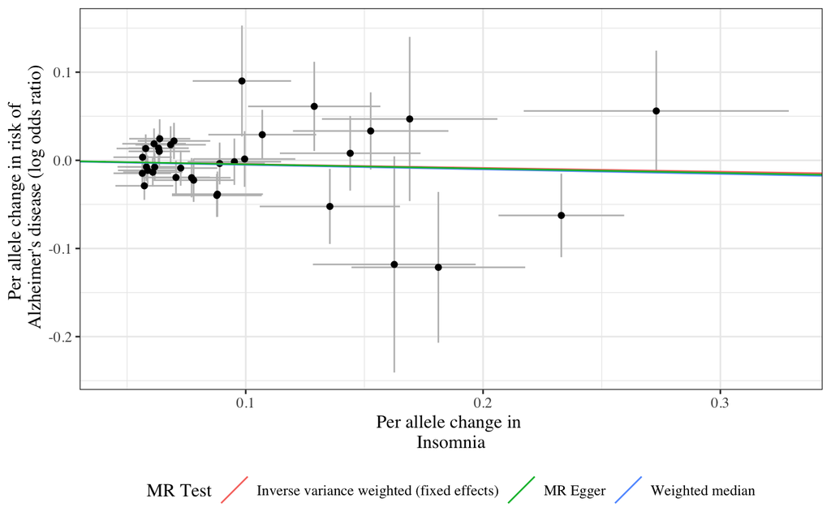

Fig. 1: Scatterplot of SNP effects for the association of Trait and LOAD

Figure 2 and Table 1 shows the SNP-specific effects and overall IVW, weighted median and Egger regression causal estimates of genetically predicted Insomnia on risk of LOAD.

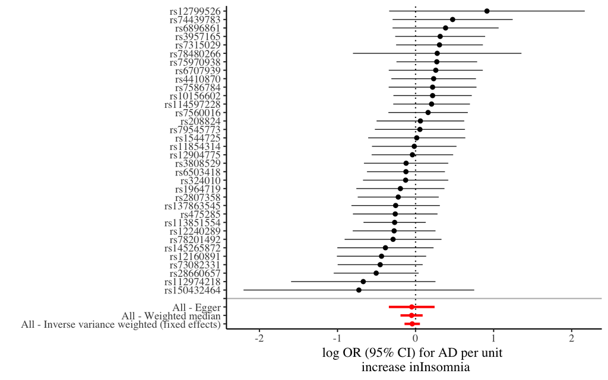

Fig. 2: Forrest plot of Wald ratios and 95% CIs for SNP-specific and overall IVW, Weighted median and Egger associations

**Table 1:** MR estimates for Insomnia and LOAD

|  | SNP | b | se | p |
| --- | --- | --- | --- | --- |
| 1 | rs10156602 | 0.21813698 | 0.25607385 | 0.39429632 |
| 2 | rs112974218 | -0.67008887 | 0.47193244 | 0.15564173 |
| 3 | rs113851554 | -0.26826337 | 0.20345094 | 0.18731445 |
| 4 | rs114597228 | 0.20513572 | 0.25055863 | 0.41294992 |
| 5 | rs11854314 | -0.01680549 | 0.27624019 | 0.95148942 |
| 6 | rs12160891 | -0.43601680 | 0.29181333 | 0.13513291 |
| 7 | rs12240289 | -0.27477586 | 0.27052675 | 0.30976903 |
| 8 | rs12799526 | 0.91466203 | 0.63924713 | 0.15247533 |
| 9 | rs12904775 | -0.04044580 | 0.26626820 | 0.87926681 |
| 10 | rs137863545 | -0.25521110 | 0.28889378 | 0.37701583 |

[output cut: 27 more lines]

Figure 3 shows a funnel plot to detect pleiotropy and Table 2 show the results of Cochrans Q heterogeneity test to assess for the presence of pleiotropy.

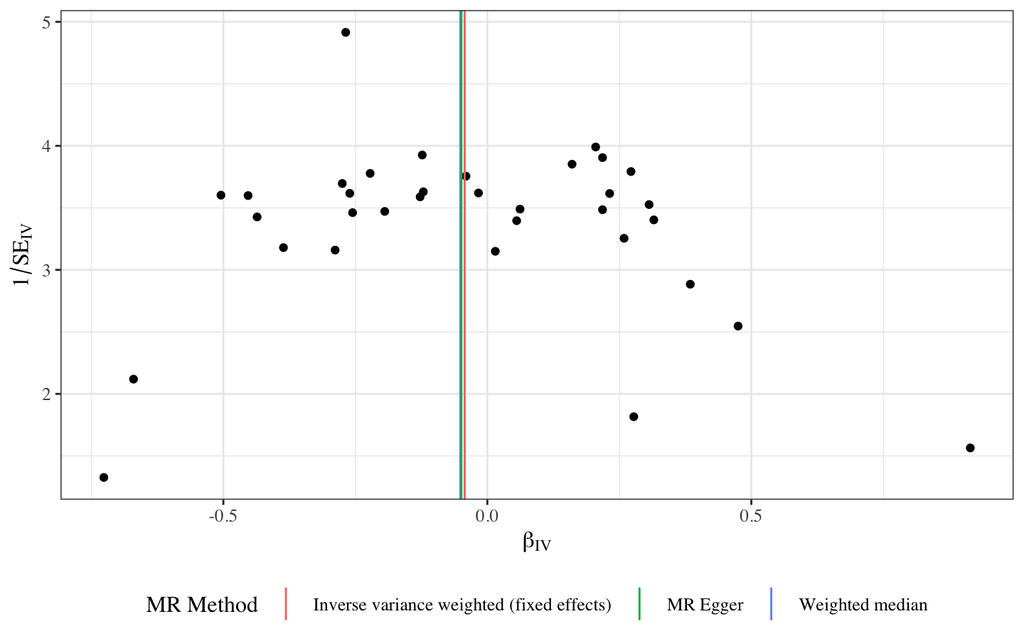

Fig. 3: Funnel plot of the Trait – LOAD causal estimates against their precession

**Table 2:** Heterogenity tests for Insomnia and LOAD

| exposure | outcome | method | Q | Q_df | Q_pval |
| --- | --- | --- | --- | --- | --- |
| insom | LOAD | MR Egger | 31.23645 | 32 | 0.5050236 |
| insom | LOAD | Inverse variance weighted | 31.23837 | 33 | 0.5549900 |

**Table 3:** Test for directional pleitropy for Insomnia and LOAD

| id.exposure | id.outcome | outcome | exposure | egger_intercept | se | pval |
| --- | --- | --- | --- | --- | --- | --- |
| mdOUtI | lkAOO0 | LOAD | insom | 0.0004951298 | 0.01130155 | 0.9653275 |

### Insomnia ~ AAOS

Figure 4 illustrates the SNP-specific associations with Insomnia versus the association between each SNP and AAOS.

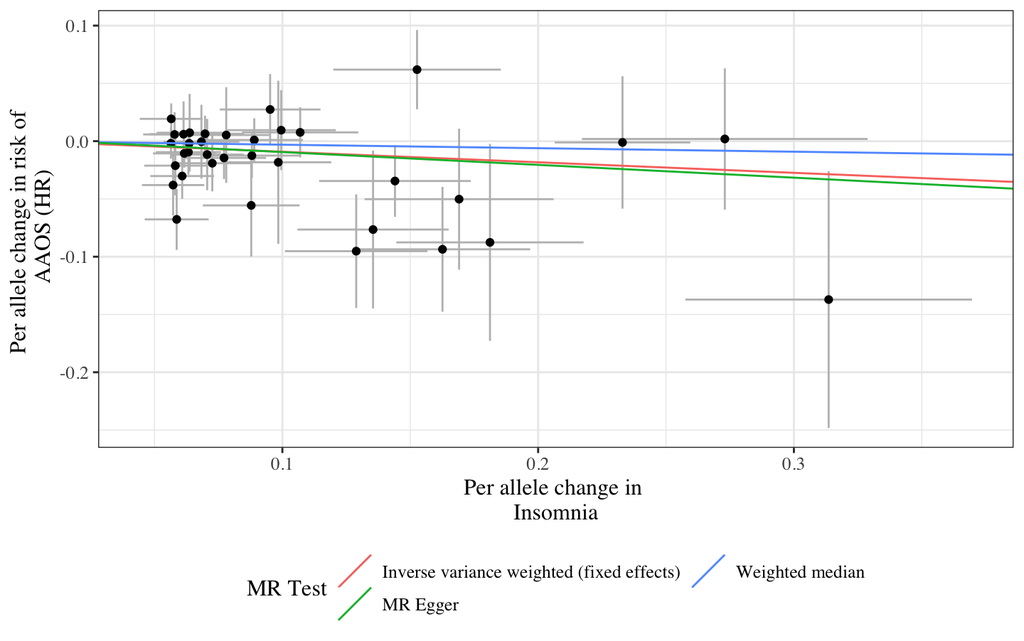

Fig. 4: Scatterplot of SNP effects for the association of Trait and AAOS

Figure 5 and Table 4 shows the SNP-specific effects and overall IVW, weighted median and Egger regression causal estimates of genetically predicted Insomnia on AAOS.

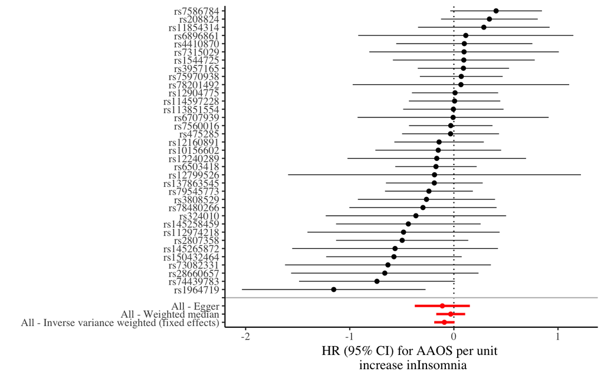

Fig. 5: Forrest plot of Wald ratios and 95% CIs for SNP-specific and overall IVW, Weighted median and Egger associations

**Table 4:** MR estimates for Insomnia and AAOS

|  | SNP | b | se | p |
| --- | --- | --- | --- | --- |
| 1 | rs10156602 | -0.150166764 | 0.30823704 | 0.62613114 |
| 2 | rs112974218 | -0.483523762 | 0.47082850 | 0.30443758 |
| 3 | rs113851554 | -0.004721435 | 0.24594386 | 0.98468379 |
| 4 | rs114597228 | 0.006959962 | 0.22381772 | 0.97519253 |
| 5 | rs11854314 | 0.287793965 | 0.32245528 | 0.37212063 |
| 6 | rs12160891 | -0.141932554 | 0.21914386 | 0.51719945 |
| 7 | rs12240289 | -0.164298967 | 0.43765846 | 0.70735964 |
| 8 | rs12799526 | -0.185981280 | 0.71750155 | 0.79547569 |
| 9 | rs12904775 | 0.011234945 | 0.21121697 | 0.95757934 |
| 10 | rs137863545 | -0.187845733 | 0.23707427 | 0.42815678 |

[output cut: 28 more lines]

Figure 6 shows a funnel plot to detect pleiotropy and Table 5 show the results of Cochrans Q heterogeneity test to assess for the presence of pleiotropy.

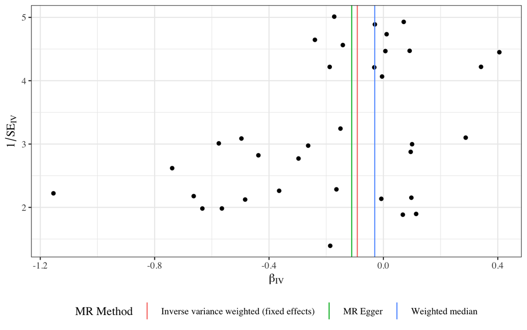

**Table 5:** Heterogenity tests for Insomnia and AAOS

| exposure | outcome | method | Q | Q_df | Q_pval |
| --- | --- | --- | --- | --- | --- |
| insom | AAOS | MR Egger | 31.94003 | 33 | 0.5197393 |
| insom | AAOS | Inverse variance weighted | 31.96420 | 34 | 0.5677385 |

**Table 6:** Test for directional pleitropy for Insomnia and AAOS

| id.exposure | id.outcome | outcome | exposure | egger_intercept | se | pval |
| --- | --- | --- | --- | --- | --- | --- |
| mdOUtI | jNOLmK | AAOS | insom | 0.00167614 | 0.01078206 | 0.8774085 |

### Insomnia ~ AB42

Figure 1 illustrates the SNP-specific associations with Insomnia versus the association between each SNP and AB42.

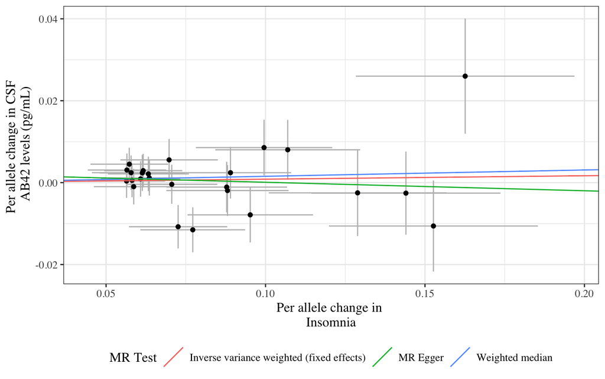

Fig. 1: Scatterplot of SNP effects for the association of trait and AB42

Figure 2 and Table 7 shows the SNP-specific effects and overall IVW, weighted median and Egger regression causal estimates of genetically predicted Insomnia CSF AB42 levels.

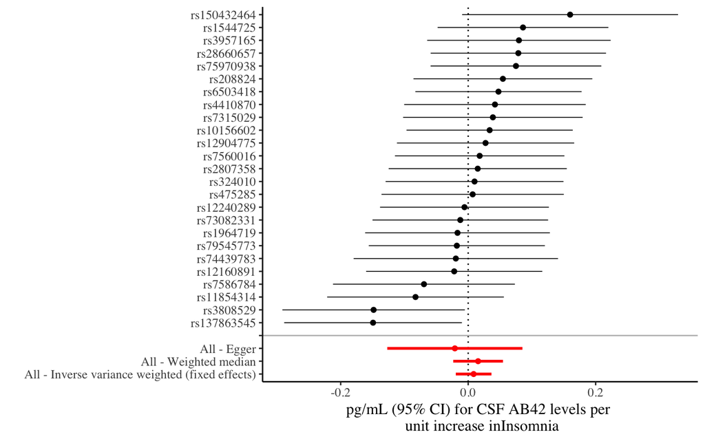

Fig. 2: Forrest plot of Wald ratios and 95% CIs for SNP-specific and overall IVW, Weighted median and Egger associations

**Table 7:** MR estimates for Insomnia and AB42

|  | SNP | b | se | p |
| --- | --- | --- | --- | --- |
| 1 | rs10156602 | 0.033668969 | 0.06653178 | 0.61281562 |
| 2 | rs11854314 | -0.082619975 | 0.07073009 | 0.24276556 |
| 3 | rs12160891 | -0.021925741 | 0.07050074 | 0.75580050 |
| 4 | rs12240289 | -0.005814201 | 0.06757503 | 0.93143409 |
| 5 | rs12904775 | 0.027255977 | 0.07094868 | 0.70085639 |
| 6 | rs137863545 | -0.149240196 | 0.07112228 | 0.03587330 |
| 7 | rs150432464 | 0.159901599 | 0.08640836 | 0.06423665 |
| 8 | rs1544725 | 0.085982398 | 0.06833983 | 0.20833413 |
| 9 | rs1964719 | -0.016739675 | 0.07394024 | 0.82089449 |
| 10 | rs208824 | 0.054460874 | 0.07156502 | 0.44665795 |

[output cut: 18 more lines]

Figure 3 shows a funnel plot to detect pleiotropy and Table 8 show the results of Cochrans Q heterogeneity test to assess for the presence of pleiotropy.

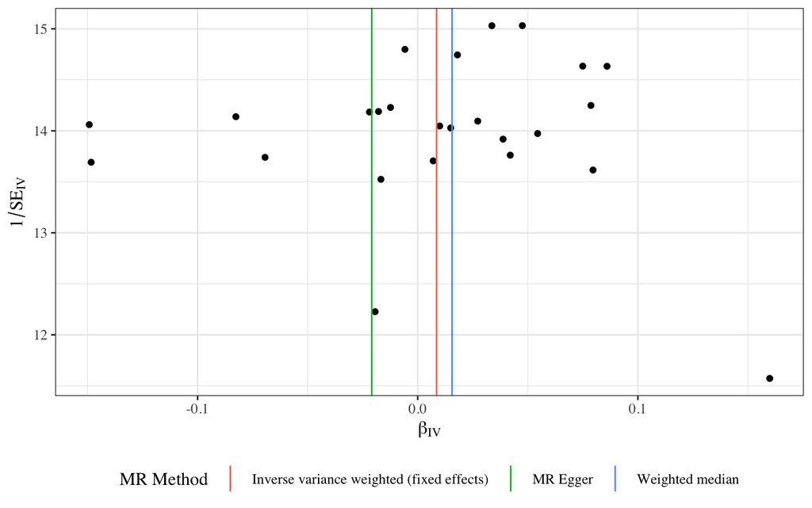

Fig. 3: Funnel plot of the trait – AB42 causal estimates against their precession

**Table 8:** Heterogenity tests for Insomnia and AB42

| exposure | outcome | method | Q | Q_df | Q_pval |
| --- | --- | --- | --- | --- | --- |
| insom | ab42 | MR Egger | 21.33577 | 23 | 0.5605903 |
| insom | ab42 | Inverse variance weighted | 21.65419 | 24 | 0.5998981 |

**Table 9:** Test for directional pleitropy for Insomnia and AB42

| id.exposure | id.outcome | outcome | exposure | egger_intercept | se | pval |
| --- | --- | --- | --- | --- | --- | --- |
| mdOUtI | xKc383 | ab42 | insom | 0.002198025 | 0.003895227 | 0.5780209 |

### Insomnia ~ Ptau

Figure 1 illustrates the SNP-specific associations with Insomnia versus the association between each SNP and risk of Ptau.

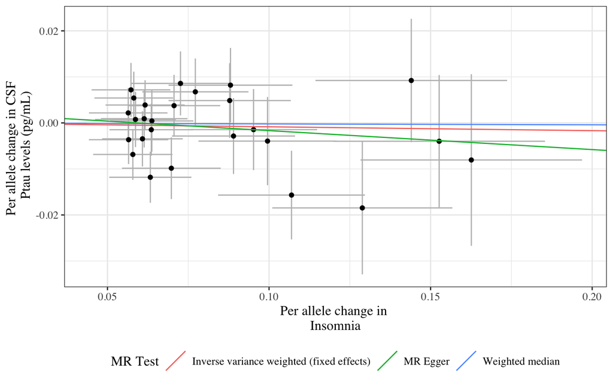

Fig. 1: Scatterplot of SNP effects for the association of trait and Ptau

Figure 2 and Table 9 shows the SNP-specific effects and overall IVW, weighted median and Egger regression causal estimates of genetically predicted Insomnia on risk of Ptau.

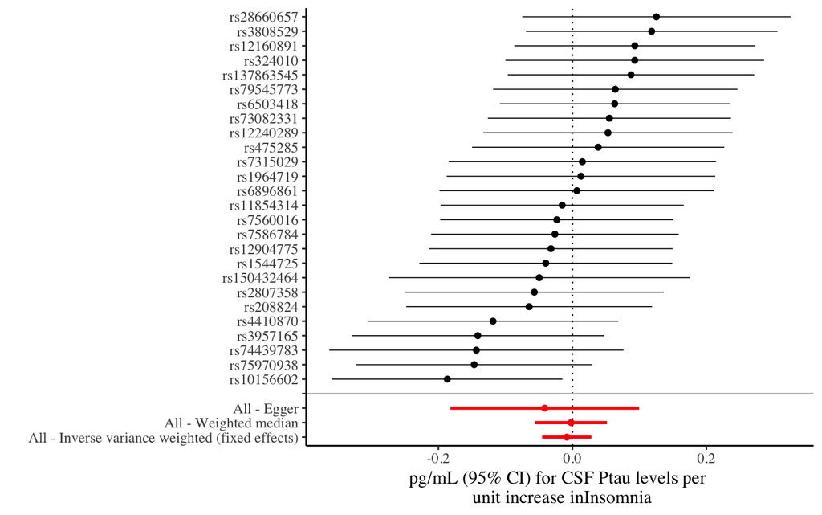

Fig. 2: Forrest plot of Wald ratios and 95% CIs for SNP-specific and overall IVW, Weighted median and Egger associations

**Table 9:** MR estimates for Insomnia and Ptau

|  | SNP | b | se | p |
| --- | --- | --- | --- | --- |
| 1 | rs10156602 | -0.186680998 | 0.08771320 | 0.03331127 |
| 2 | rs11854314 | -0.015303497 | 0.09254572 | 0.86865947 |
| 3 | rs12160891 | 0.093130464 | 0.09177927 | 0.31023824 |
| 4 | rs12240289 | 0.053085563 | 0.09486849 | 0.57577276 |
| 5 | rs12904775 | -0.032019594 | 0.09265459 | 0.72965822 |
| 6 | rs137863545 | 0.087458382 | 0.09381923 | 0.35123263 |
| 7 | rs150432464 | -0.049538745 | 0.11469865 | 0.66581156 |
| 8 | rs1544725 | -0.039695776 | 0.09627055 | 0.68009344 |
| 9 | rs1964719 | 0.012729039 | 0.10226866 | 0.90094579 |
| 10 | rs208824 | -0.064560634 | 0.09360408 | 0.49037008 |

[output cut: 19 more lines]

Figure 3 shows a funnel plot to detect pleiotropy and Table 10 show the results of Cochrans Q heterogeneity test to assess for the presence of pleiotropy.

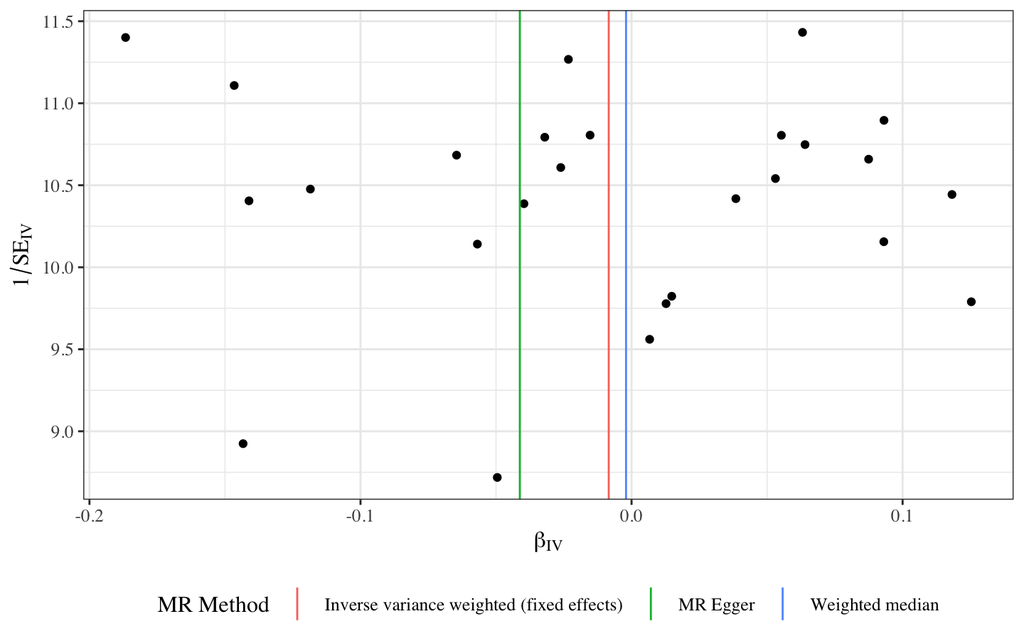

Fig. 3: Funnel plot of the trait – Ptau causal estimates against their precession

**Table 10:** Heterogenity tests for Insomnia and Ptau

| exposure | outcome | method | Q | Q_df | Q_pval |
| --- | --- | --- | --- | --- | --- |
| insom | ptau | MR Egger | 21.23519 | 24 | 0.6248150 |
| insom | ptau | Inverse variance weighted | 21.45908 | 25 | 0.6667524 |

**Table 11:** Test for directional pleitropy for Insomnia and Ptau

| id.exposure | id.outcome | outcome | exposure | egger_intercept | se | pval |
| --- | --- | --- | --- | --- | --- | --- |
| mdOUtI | 71GhQ0 | ptau | insom | 0.002446792 | 0.00517099 | 0.6403626 |

### Insomnia ~ Tau

Figure 1 illustrates the SNP-specific associations with Insomnia versus the association between each SNP and CSF Tau levels.

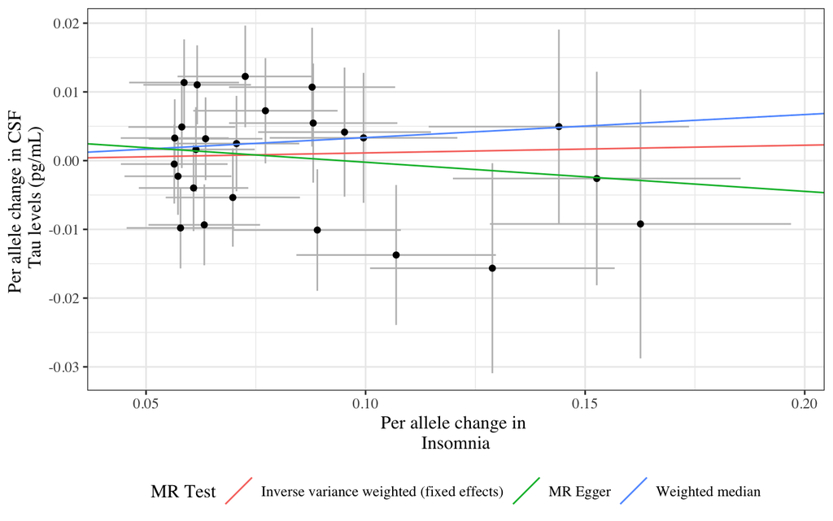

Fig. 1: Scatterplot of SNP effects for the association of trait and Tau

Figure 2 and Table 12 shows the SNP-specific effects and overall IVW, weighted median and Egger regression causal estimates of genetically predicted Insomnia on risk of Tau.

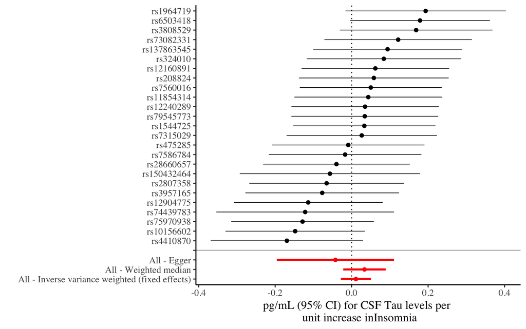

Fig. 2: Forrest plot of Wald ratios and 95% CIs for SNP-specific and overall IVW, Weighted median and Egger associations

**Table 12:** MR estimates for Insomnia and Tau

|  | SNP | b | se | p |
| --- | --- | --- | --- | --- |
| 1 | rs10156602 | -0.14768506 | 0.09296113 | 0.11213370 |
| 2 | rs11854314 | 0.04357873 | 0.09865871 | 0.65869769 |
| 3 | rs12160891 | 0.06204156 | 0.09847848 | 0.52869383 |
| 4 | rs12240289 | 0.03518264 | 0.09831027 | 0.72043798 |
| 5 | rs12904775 | -0.11347295 | 0.09931692 | 0.25323215 |
| 6 | rs137863545 | 0.09401355 | 0.09916959 | 0.34312546 |
| 7 | rs150432464 | -0.05666667 | 0.12029520 | 0.63759546 |
| 8 | rs1544725 | 0.03325564 | 0.09496443 | 0.72619578 |
| 9 | rs1964719 | 0.19362866 | 0.10705824 | 0.07050863 |
| 10 | rs208824 | 0.05808688 | 0.09988326 | 0.56087136 |

[output cut: 18 more lines]

Figure 3 shows a funnel plot to detect pleiotropy and Table 13 show the results of Cochrans Q heterogeneity test to assess for the presence of pleiotropy.

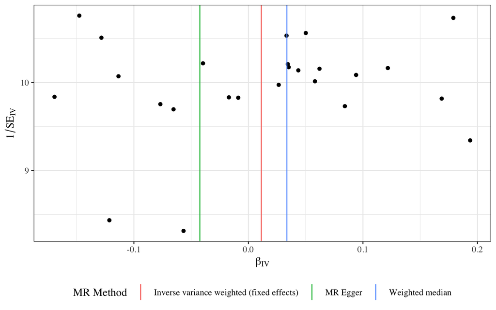

Fig. 3: Funnel plot of the trait – Tau causal estimates against their precession

**Table 14:** Heterogenity tests for Insomnia and Tau

| exposure | outcome | method | Q | Q_df | Q_pval |
| --- | --- | --- | --- | --- | --- |
| insom | tau | MR Egger | 24.46194 | 23 | 0.3786104 |
| insom | tau | Inverse variance weighted | 24.99978 | 24 | 0.4057726 |

**Table 15:** Test for directional pleitropy for Insomnia and Tau

| id.exposure | id.outcome | outcome | exposure | egger_intercept | se | pval |
| --- | --- | --- | --- | --- | --- | --- |
| mdOUtI | KV3TLz | tau | insom | 0.00401051 | 0.005639669 | 0.4841569 |

### Insomnia ~ HV

Figure 1 illustrates the SNP-specific associations with Insomnia versus the association between each SNP and hippocampal volume.

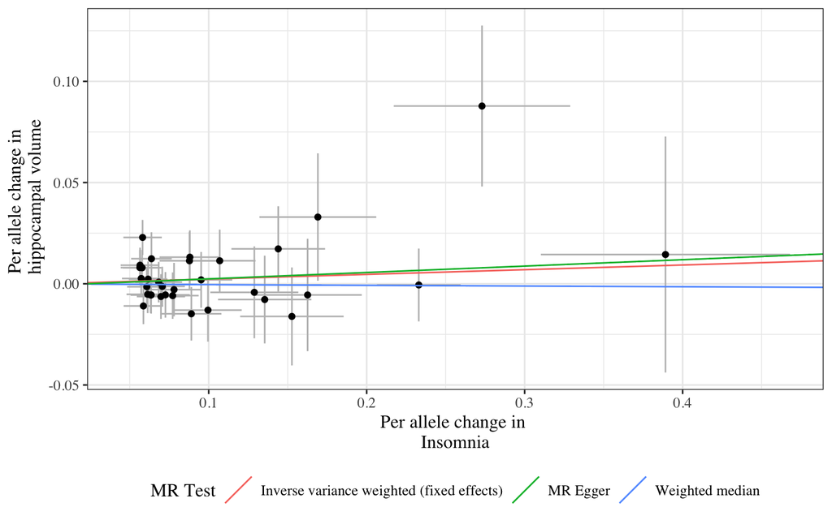

Fig. 1: Scatterplot of SNP effects for the association of trait and hippocampal volume

Figure 2 and Table 12 shows the SNP-specific effects and overall IVW, weighted median and Egger regression causal estimates of genetically predicted Insomnia on risk of hippocampal volume.

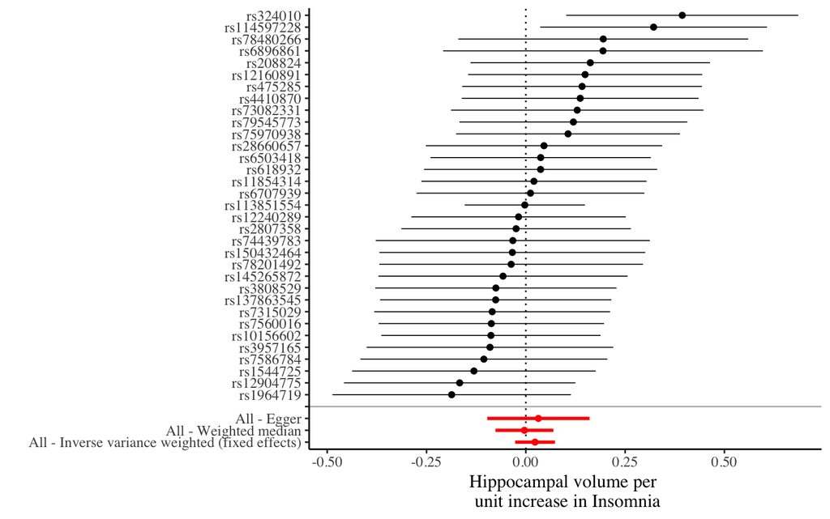

Fig. 2: Forrest plot of Wald ratios and 95% CIs for SNP-specific and overall IVW, Weighted median and Egger associations

**Table 12:** MR estimates for Insomnia and hippocampal volume

|  | SNP | b | se | p |
| --- | --- | --- | --- | --- |
| 1 | rs10156602 | -0.087840492 | 0.14077002 | 0.532627585 |
| 2 | rs113851554 | -0.002548421 | 0.07722488 | 0.973674588 |
| 3 | rs114597228 | 0.321642583 | 0.14567146 | 0.027244273 |
| 4 | rs11854314 | 0.020390513 | 0.14461356 | 0.887869942 |
| 5 | rs12160891 | 0.149289871 | 0.15034227 | 0.320709954 |
| 6 | rs12240289 | -0.018316970 | 0.13772158 | 0.894193380 |
| 7 | rs12904775 | -0.166548689 | 0.14870419 | 0.262713762 |
| 8 | rs137863545 | -0.075892129 | 0.14851689 | 0.609351057 |
| 9 | rs145265872 | -0.057443981 | 0.16001109 | 0.719595089 |
| 10 | rs150432464 | -0.033971981 | 0.17071347 | 0.842262745 |

[output cut: 26 more lines]

Figure 3 shows a funnel plot to detect pleiotropy and Table 13 show the results of Cochrans Q heterogeneity test to assess for the presence of pleiotropy.

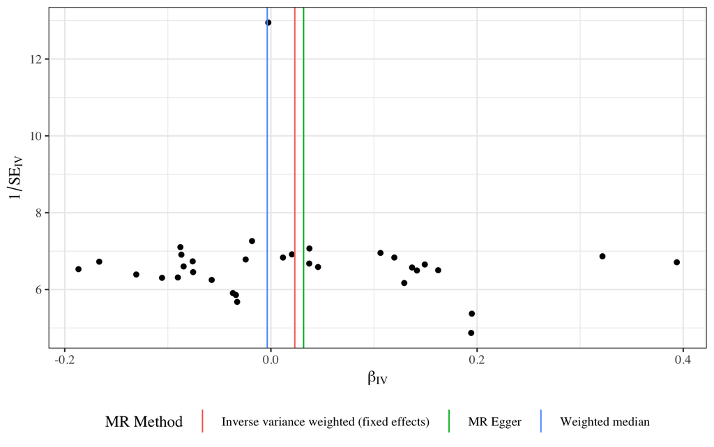

Fig. 3: Funnel plot of the trait – hippocampal volume causal estimates against their precession

**Table 14:** Heterogenity tests for Insomnia and hippocampal volume

| exposure | outcome | method | Q | Q_df | Q_pval |
| --- | --- | --- | --- | --- | --- |
| insom | hipv | MR Egger | 24.92430 | 31 | 0.7710937 |
| insom | hipv | Inverse variance weighted | 24.94411 | 32 | 0.8082861 |

**Table 15:** Test for directional pleitropy for Insomnia and hippocampal volume

| id.exposure | id.outcome | outcome | exposure | egger_intercept | se | pval |
| --- | --- | --- | --- | --- | --- | --- |
| mdOUtI | g9jpsS | hipv | insom | -0.0007372974 | 0.005238675 | 0.888985 |

## MR analysis results

| exposure | outcome | method | nsnp | b | se | pval | Signif |
| --- | --- | --- | --- | --- | --- | --- | --- |
| insom | LOAD | IVW | 34 | -0.042887236 | 0.05023077 | 0.39321359 |  |
| insom | LOAD | Weighted median | 34 | -0.051228324 | 0.07204403 | 0.47704109 |  |
| insom | LOAD | MR Egger | 34 | -0.049053916 | 0.14945138 | 0.74487848 |  |
| insom | AAOS | IVW | 35 | -0.091344668 | 0.04964045 | 0.06574976 | . |
| insom | AAOS | Weighted median | 35 | -0.030361078 | 0.06967747 | 0.66302729 |  |
| insom | AAOS | MR Egger | 35 | -0.110860121 | 0.13499474 | 0.41741554 |  |
| insom | ab42 | IVW | 25 | 0.008546636 | 0.01427264 | 0.54929782 |  |
| insom | ab42 | Weighted median | 25 | 0.015570633 | 0.01993791 | 0.43482828 |  |
| insom | ab42 | MR Egger | 25 | -0.020895826 | 0.05409331 | 0.70283071 |  |
| insom | ptau | IVW | 26 | -0.008412310 | 0.01879402 | 0.65443786 |  |

[output cut: 8 more lines]